# Red wine quality analysis

Author: Jeremy Tran  
Email: jeremytran251@gmail.com

## 1. Exploratory data analysis

```python
# Load libraries
import numpy as np
import pandas as pd
import matplotlib.pyplot as plt
import seaborn as sns
from sklearn.model_selection import cross_val_score
from sklearn.model_selection import train_test_split
from sklearn.metrics import roc_auc_score, accuracy_score, confusion_matrix, classification_report
from sklearn.metrics import f1_score, average_precision_score

# import warnings filter
from warnings import simplefilter
from sklearn.exceptions import FitFailedWarning
# ignore all future warnings
simplefilter(action='ignore', category=FutureWarning)
```

```python
# Read csv file
wines = pd.read_csv('/content/winequality-red.csv')

# Display the first 5 rows of the data
wines.head()
```

|  | fixed acidity | volatile acidity | citric acid | residual sugar | chlorides | free sulfur dioxide | total sulfur dioxide | density | pH | sulphates | alcohol | quality |
| --- | --- | --- | --- | --- | --- | --- | --- | --- | --- | --- | --- | --- |
| 0 | 7.4 | 0.70 | 0.00 | 1.9 | 0.076 | 11.0 | 34.0 | 0.9978 | 3.51 | 0.56 | 9.4 | 5 |
| 1 | 7.8 | 0.88 | 0.00 | 2.6 | 0.098 | 25.0 | 67.0 | 0.9968 | 3.20 | 0.68 | 9.8 | 5 |
| 2 | 7.8 | 0.76 | 0.04 | 2.3 | 0.092 | 15.0 | 54.0 | 0.9970 | 3.26 | 0.65 | 9.8 | 5 |
| 3 | 11.2 | 0.28 | 0.56 | 1.9 | 0.075 | 17.0 | 60.0 | 0.9980 | 3.16 | 0.58 | 9.8 | 6 |
| 4 | 7.4 | 0.70 | 0.00 | 1.9 | 0.076 | 11.0 | 34.0 | 0.9978 | 3.51 | 0.56 | 9.4 | 5 |

```python
# Print data shape
shape = wines.shape
print('Number of rows:', shape[0])
print('Number of columns:', shape[1])
```

```
Number of rows: 1599
Number of columns: 12
```

```python
# Check null values
print('The number of nulls in each column:')
print(wines.isnull().sum())
```

```
The number of nulls in each column:
fixed acidity           0
volatile acidity        0
citric acid             0
residual sugar          0
chlorides               0
free sulfur dioxide     0
total sulfur dioxide    0
density                 0
pH                      0
sulphates               0
alcohol                 0
quality                 0
dtype: int64
```

```python
wines.info()
```

```
<class 'pandas.core.frame.DataFrame'>
RangeIndex: 1599 entries, 0 to 1598
Data columns (total 12 columns):
 #   Column                Non-Null Count  Dtype
---  ------                --------------  -----
 0   fixed acidity         1599 non-null   float64
 1   volatile acidity      1599 non-null   float64
 2   citric acid           1599 non-null   float64
 3   residual sugar        1599 non-null   float64
 4   chlorides             1599 non-null   float64
 5   free sulfur dioxide   1599 non-null   float64
 6   total sulfur dioxide  1599 non-null   float64
 7   density               1599 non-null   float64
 8   pH                    1599 non-null   float64
 9   sulphates             1599 non-null   float64
 10  alcohol               1599 non-null   float64
 11  quality               1599 non-null   int64
dtypes: float64(11), int64(1)
memory usage: 150.0 KB
```

The data has 1599 rows and 12 columns, and there is none null value exhibited. As we can see from the code below, most of wines in this dataset have 5, 6, and 7 quality scores.

```python
wines.quality.value_counts()
```

```
5    681
6    638
7    199
4     53
8     18
3     10
Name: quality, dtype: int64
```

In this analysis, we will try to create a machine learning model that precisely predict the quality of the wine based on its elements and chemistry. We assume that the ones having 7 or higher quality scores are good wines, while the rest are bad ones (having less than 7 score).

```python
# Condition for the new column:
# quality >= 7: class 1 (good wine)
# quality < 7: class 0 (not good wine)
condition = [(wines.quality >= 7),
             (wines.quality < 7)]

classes = [1, 0]

# Create new classes with the condition
wines['class'] = np.select(condition, classes)
```

After that, we assign features (`X`) and target (`y`) from the dataset before checking the correlation between variables.

```python
# Assign features
# Exclude 'quality' and 'class' (the last 2 columns) in X to avoid leakage
X = wines.iloc[:, :-2]

# Assign target
y = wines.iloc[:, -1]
```

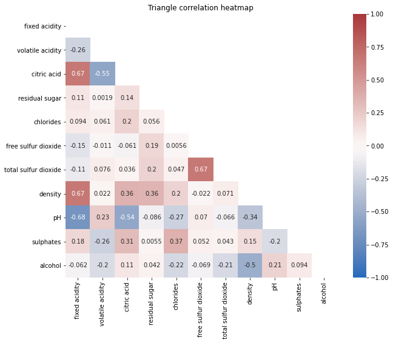

```python
# Create correlation heatmap
plt.figure(figsize=(10, 8))
mask = np.triu(np.ones_like(X.corr(), dtype=np.bool))
sns.heatmap(X.corr(), vmin=-1, vmax=1, annot=True,
            annot_kws={"size": 10}, cmap='vlag', mask=mask)
plt.title('Triangle correlation heatmap')
plt.show()
```

The correlation heatmap has illustrated that some variables are moderately correlated, especially the feature `fixed acidity` having moderate correlation with 3 other variables, which exposes to risk of multicollinearity. However, the correlation is not strong and the data size is relatively small so the effect could be insignificant.

```python
# Check class balance
y.value_counts()
```

```
0    1382
1     217
Name: class, dtype: int64
```

After translating the target variable into binary label, it is clearly that there is an imbalanced class problem in the dataset that the number of instances of class 1 is moderately smaller than the number of instances of class 0.

- Class 1: good wine
- Class 0: bad wine

## 2. Model selection

First of all, it should be noted that the ultimate goal of this analysis is to precisely classify the good wine, which means the positive class is more important than the negative one. Hence, we could select one of these PR AUC, ROC AUC, or F-beta score as the main metric. However, the EDA in the first section has indicated that the data has imbalanced classes so we should not use ROC AUC because this metric only works well when the ratios of both classes are relatively similar and both classes detection is equally important. Furthermore, we would like to predict the probabilities rather than the label so that we could adjust the threshold to deal with the imbalanced class problem. Therefore, the **PR AUC** should be chosen to be the main metric because it fits to our goal and works well on the heavily imbalanced data.

In the first step of the analysis, we will try to fit the data on several models with default setting to find out which one returns the best Precision - Recall curve. One way to do that is to compute the **Average Precision score** of each model and compare the result. The Average Precision score is the avarage precision at all such possible thresholds of the PR curve, and it is an useful metric to compare how well models are ordering the predictions, without considering any specific decision threshold. Another important reason to compute Average Precision score rather than F1 score is that we might want to favour the precision. The final model should be precision-oriented because False Negative hurts performance more than False Positive. On other words, we want to reduce as much as possible the number of true good wines that are wrongly predicted as bad one because the wrong prediction might negatively affect the sales and reputation of good wine brewers.

Before applying a number of supervised learning methods, I would like to try 2 unsupervised learning models on the data as well. The first model is K-means clustering, and the second one is more sophisticated that it illustrates the data into 2 dimensional, which is called t-SNE.

### 2.1. K-means clustering

```python
# Scale data by MinMaxScaler
from sklearn.preprocessing import MinMaxScaler

X_scaled = MinMaxScaler().fit_transform(X)
```

```python
from sklearn.cluster import KMeans

# Create KMeans model object
kmeans = KMeans(n_clusters=2, random_state=0)

# Fit and transform X_scaled to 2 dimensional
X_kmeans = kmeans.fit_transform(X_scaled)
```

```
K-Means accuracy score: 0.647
K-Means average precision score: 0.208
              precision    recall  f1-score   support

           0       0.94      0.64      0.76      1382
           1       0.24      0.72      0.36       217

    accuracy                           0.65      1599
   macro avg       0.59      0.68      0.56      1599
weighted avg       0.84      0.65      0.70      1599
```

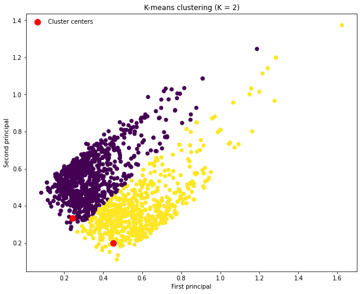

```python
# Create a data frame that contain KMeans result
points_kmeans = pd.DataFrame(X_kmeans)
points_kmeans.columns = ['First principal', 'Second principal']
points_kmeans['Label'] = kmeans.predict(X_scaled)

# Print result
print('K-Means accuracy score: {:.3f}'
.format(accuracy_score(y, points_kmeans['Label'])))
print('K-Means average precision score: {:.3f}'
.format(average_precision_score(y, points_kmeans['Label'])))
print(classification_report(y, points_kmeans['Label']))

# Plot the figure
plt.figure(figsize=(10, 8))
# Plot the scatter plot
plt.scatter(points_kmeans['First principal'],
            points_kmeans['Second principal'],
            c = points_kmeans['Label'])
# Find cluster centers from the K-Means
centers = kmeans.cluster_centers_
# Plot the cluster centers
plt.scatter(centers[:, 0], centers[:, 1], c='red', s=100, label='Cluster centers')
# Change x, y labels, and add legend to the plot
plt.xlabel('First principal')
plt.ylabel('Second principal')
plt.title('K-means clustering (K = 2)')
plt.legend(frameon=False)
plt.show()
```

### 2.2. t-SNE

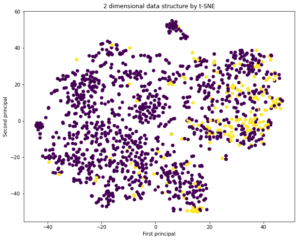

```python
from sklearn.manifold import TSNE
from sklearn.preprocessing import StandardScaler

# Standardized data by StandardScaler
X_std = StandardScaler().fit_transform(X)

# Scale data to 2 dimensional space
tsne = TSNE(n_components=2, perplexity=40,
            learning_rate=100, random_state=0)
X_tsne = tsne.fit_transform(X_std)

# Plot the figure
plt.figure(figsize=(10, 8))
plt.scatter(X_tsne[:, 0], X_tsne[:, 1], c=y)
plt.xlabel('First principal')
plt.ylabel('Second principal')
plt.title('2 dimensional data structure by t-SNE')
plt.show()
```

t-SNE is a strong and sophisticated unsupervised learning algorithm that helps to present complex data with many dimensions on the 2-dimensional space. It could be witnessed from the figure is that this algorithm does not work well on this dataset as class 1 and class 0 are not well seperated.

### 2.3. Supervised learning models

Let's see how imbalanced the data is.

```python
# Print the number of instances in each class
for i in [0, 1]:
  instances = y.value_counts()[i]
  total = y.value_counts().sum()
  proportion = instances * 100 / y.value_counts().sum()
  print('Class {0}: {1}/{2} ({3:.2f}%)'.format(i, instances, total, proportion))
```

```
Class 0: 1382/1599 (86.43%)
Class 1: 217/1599 (13.57%)
```

Instead of calculating the average precision score for each model manually, the helper function defined below will make the job faster.

In this analysis, the Over-sampling technique and stratified k fold cross validation will be applied to reduce the effect of imbalanced data on the model performance. To avoid leakage, the Over-sampling will only be applied after doing stratified K-fold.

```python
# Support function to compute average F1 score from stratified K-fold cross validation
def avg_precision_score(model, k):
  """Compute the average average precision score from the given model by using
  stratified K-fold cross validation
  Parameters: model: the model
              K: the number of folds
  """
  import numpy as np
  from sklearn.model_selection import StratifiedKFold
  from sklearn.metrics import average_precision_score
  from imblearn.over_sampling import SMOTE
  from sklearn.preprocessing import MinMaxScaler

  # Create stratified k-fold object
  kfold = StratifiedKFold(n_splits=k, shuffle=True, random_state=0)

  # Compute F1 scores from each fold
  avg_precision_scores = []
  for train_index, test_index in kfold.split(X, y):
    # Assign train & test dataset
    X_train, X_test = X.loc[train_index], X.loc[test_index]
    y_train, y_test = y.loc[train_index], y.loc[test_index]

    # Define oversample strategy
    oversample = SMOTE(sampling_strategy=0.5)
    # Fit and the transformation on the train data
    X_over, y_over = oversample.fit_resample(X_train, y_train)

    # Scale data by MinMaxScaler
    scaler = MinMaxScaler()
    X_over_train_scaled = scaler.fit_transform(X_over)
    X_over_test_scaled = scaler.transform(X_test)

    # Fit the model to the current fold data
    model.fit(X_over_train_scaled, y_over)
    # Use the trained model to predict the unseen dataset
    y_pred = model.predict(X_over_test_scaled)

    # Compute the F1 score of the current fold and add it to the list of F1 scores
    avg_precision = average_precision_score(y_test, y_pred)
    avg_precision_scores.append(avg_precision)

  # Compute the average F1 score
  result = np.mean(avg_precision_scores)

  return result
```

Let's apply the helper function to each model.

```python
from sklearn.ensemble import RandomForestClassifier
from sklearn.svm import SVC
from sklearn.linear_model import LogisticRegression
from sklearn.model_selection import cross_val_score
from sklearn.svm import SVC

# Logistic Regression
lr = LogisticRegression(max_iter=1000, C=1, random_state=0)

# Support Vectore Machine Classifier
svc = SVC(kernel='rbf', random_state=0)

# Random Forest Classifier
# Set max_features = 5, max_depth = 5, and n_estimators = 100 to avoid overfitting
rf = RandomForestClassifier(random_state=0, max_features=5,
                            n_estimators=100, max_depth=5)

# Create a list of names and models
names = ['Logistic Regression', 'Support Vector Machine', 'Random Forest Classifier']
models = [lr, svc, rf]

# Use the helper function from previous code cell to compute the average
# precision score of each model by using Over Sampling and Stratified K fold method
for name, model in zip(names, models):
  avg_presicion = avg_precision_score(model, 10)
  print('Average precision score of {}: {:.3f}'.format(name, avg_presicion))
```

```
Average precision score of Logistic Regression: 0.353
Average precision score of Support Vector Machine: 0.379
Average precision score of Random Forest Classifier: 0.384
```

In general, the average precision score of three models are not substaintially different. Therefore, I personally favour the **Support Vector Machine** in this case even though it has returned the slightly lower average precision score than Random Forest Classifier. There are two main reasons for my model selection and the first one is that Support Vector Machine model could work well with Polynomial features and avoid overfitting easily by adjusting its regularization parameter (`C`). The second reason is that SMV returns result faster than RF.

In the final model below, after over-sampling the **training data** to the ratio of 0.5 (reduce the class imbalance from 1:6 to 1:2) and transforming the data into Polynomial features at the degree of 2, the grid search cross-validation will be applied on the Support Vector Machine in order to find the best parameters that return the highest average precision score. In the last step, the Precision-Recall curve will be computed and we will try to find the best threshold that favours the precision score at the acceptable level of recall.

## 3. Final model tunning

```python
from sklearn.preprocessing import PolynomialFeatures

# Define oversample strategy
oversample = SMOTE(sampling_strategy=.5)
# Fit and the transformation on the train data
X_over, y_over = oversample.fit_resample(X_train, y_train)

# Polynomial features
poly = PolynomialFeatures(degree=2)

X_train_poly = poly.fit_transform(X_over)
X_test_poly = poly.transform(X_test)

scaler = MinMaxScaler()
X_train_poly_scaled = scaler.fit_transform(X_train_poly)
X_test_poly_scaled = scaler.transform(X_test_poly)

svc = SVC(random_state=0, probability=True)

param_grid = {'kernel': ['rbf', 'linear', 'poly'],
             'C': [0.01, 0.1, 1, 10, 30],
             'gamma': [0.01, 0.1, 1, 10, 30]}

grid_svc = GridSearchCV(svc, param_grid=param_grid, scoring='average_precision')
grid_svc.fit(X_train_poly_scaled, y_over)

y_svc_pred = grid_svc.predict(X_test_poly_scaled)

print('Support Vector Machine best parameters:', grid_svc.best_params_)
print('Average precision score: {:.3f}'.format(grid_svc.best_score_))
print('Classification report at threshold = 0.5:')
print(classification_report(y_test, y_svc_pred))
```

```
Support Vector Machine best parameters: {'C': 10, 'gamma': 10, 'kernel': 'rbf'}
Average precision score: 0.973
Classification report at threshold = 0.5:
              precision    recall  f1-score   support

           0       0.93      0.96      0.95       277
           1       0.71      0.56      0.62        43

    accuracy                           0.91       320
   macro avg       0.82      0.76      0.79       320
weighted avg       0.90      0.91      0.90       320
```

The highest average precision score could be found is 0.973 at the parameters of `C = 10`, `gamma = 10`, and the kernel is RBF. At the threshold of 0.5, the precision is 0.71 and recall is 0.56, which is considered as acceptable result. However, with the very high average precision score, the precision might be improved by adjusting the threshold value. It should be noted that, due to the precision-recall trade-off, the recall will be decreased when precision is increased.

```
The best threshold: 0.972
Precision at the best threshold: 0.905
Recall at the best threshold: 0.442
```

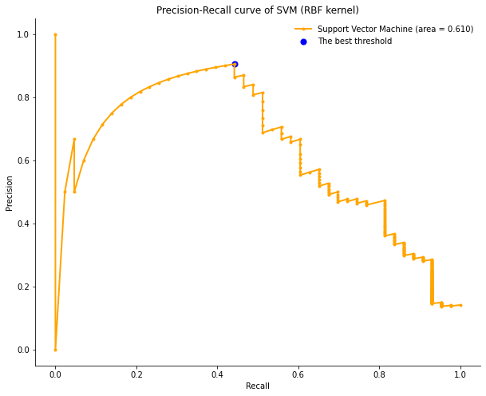

```python
from sklearn.metrics import auc

# Predict probabilities
y_proba = grid_svc.predict_proba(X_test_poly_scaled)
y_proba = y_proba[:, 1] # Only keep probabilities of positive outcome (class 1)

# Compute the PR curve
precision, recall, thresholds = precision_recall_curve(y_test, y_proba)

# Plot the precision-recall curve
plt.figure(figsize=(10, 8))
plt.plot(recall, precision, linewidth=2, marker='.', color='orange',
         label='Support Vector Machine (area = {:.3f})'.format(auc(recall, precision)))

# Find the index of the best threshold that returns the highest precision
ix = np.argmax([score for score in precision if score < 1]) # index
threshold = thresholds[ix]
# Print the precision and recall at the best threshold
print('The best threshold: {:.3f}'.format(threshold))
print('Precision at the best threshold: {:.3f}'.format(precision[ix]))
print('Recall at the best threshold: {:.3f}'.format(recall[ix]))

# Plot the best threshold
plt.scatter(recall[ix], precision[ix], marker='o', color='blue', s=50,
            label='The best threshold')

# Remove upper and right frame
ax = plt.gca()
spines = list(ax.spines.values())
spines[1].set_visible(False) # remove right frame
spines[3].set_visible(False) # remove upper frame

# Add labels and legend
plt.xlabel('Recall')
plt.ylabel('Precision')
plt.title('Precision-Recall curve of SVM (RBF kernel)')
plt.legend(frameon=False)

plt.show()
```

By moving the threshold to the value of 0.972, the precision is very high at 0.905 while the recall is only at 0.442 (the blue dot in the figure). However, this low value of recall is acceptable because it is not too small and the precision score meets the goal of this analysis. Therefore, we keep this model as our final model.